# 218x Assignment 2

Lange Luntao

12/6/2020

## Instructions

*Prepare a report analyzing education outcomes in one County (of your choice) in the Bay Area. You are welcome to include as many data-driven insights as you’d like, with the many kinds of education datasets available from the Census Bureau and elsewhere, but at the minimum, you must include:*

*- An equity analysis of educational attainment by race. Plot the “stacked” and “filled” bar charts as demonstrated in 2.2; from there, you are welcome to add as many comments and supplementary visualizations as you’d like. Essentially, respond to the question: “Is there disproportionate education attainment by race in the County?” Note that the universe of the ACS datasets on educational attainment is “population 25 years or older”, so be sure to clarify that in your visuals and commentary.*

I pulled Census data from the most recent 2019 ACS 1-year Community Survey to capture the educational attainment by race. In particular, I used variable B15002 - sex by educational attainment by race.

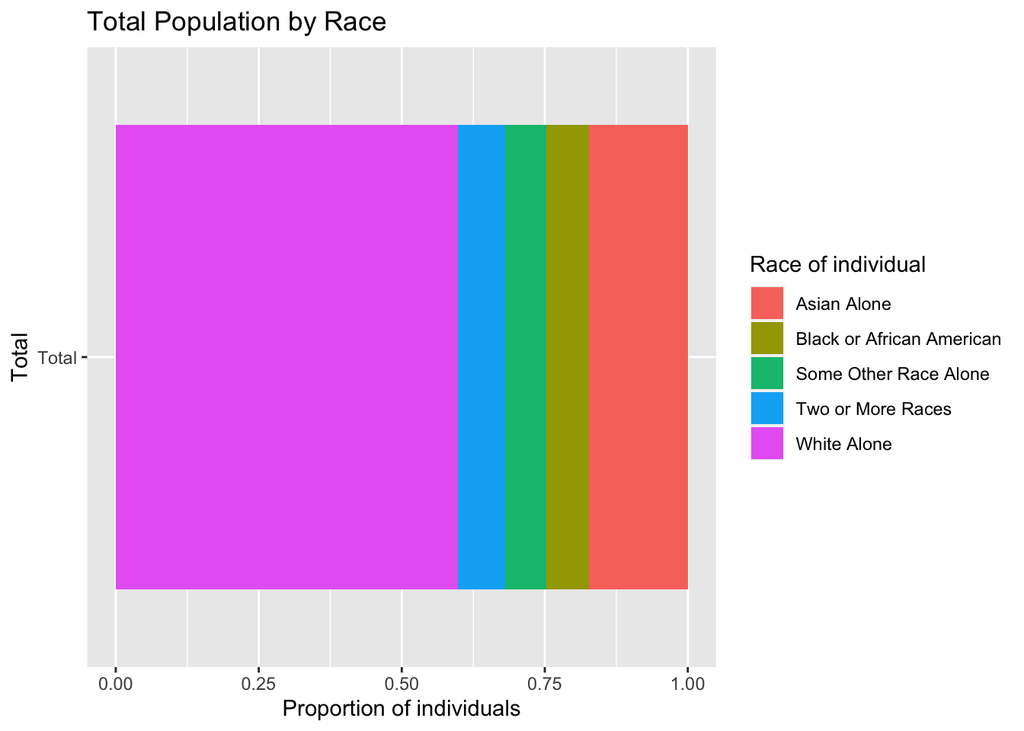

```r
sjc_education_race <-
  1:7 %>%
  map_dfr(function(x){
    getCensus(
      name = "acs/acs1",
      vintage = 2019,
      region = "county:077",
      regionin = "state:06",
      vars = paste0("group(B15002",LETTERS[x],")")
    ) %>%
      select(!c(GEO_ID,state,NAME) & !ends_with(c("EA","MA","M"))) %>%
      pivot_longer(
        ends_with("E"),
        names_to = "variable",
        values_to = "estimate"
      ) %>%
      left_join(
        acs_vars_2018_1yr %>%
          select(name, label),
        by = c("variable" = "name")
      ) %>%
      select(-variable) %>%
      separate(
        label,
        into = c(NA,NA,NA,"education"),
        sep = "!!"
      ) %>%
      filter(!is.na(education)) %>%
      mutate(race = census_race_labels[x])
  })
sjc_race_total <-
  sjc_education_race %>%
  group_by(race) %>%
  summarize(estimate = sum(estimate)) %>%
  mutate(education = "Total")
## re-order factors in sjc_education_rate by attainment
sjc_education_race$education <- factor(sjc_education_race$education,
                                       levels = c("Graduate or professional degree",
                                       "Bachelor's degree",
                                       "Associate's degree",
                                       "Some college, no degree",
                                       "Regular high school diploma",
                                       "GED or alternative credential",
                                       "9th to 12th grade, no diploma",
                                       "Less than 9th grade"))

### graph total population by race in dataset
sjc_race_total %>%
  group_by(education, race) %>%
  summarize(estimate = sum(estimate)) %>%
  ggplot() +
  geom_bar(
    aes(
      x = education,
      y = estimate,
      fill = race
    ),
    stat = "identity",
    position = "fill"
  ) +
  labs(
    x = "Total",
    y = "Proportion of individuals",
    title = "Total Population by Race",
    fill = "Race of individual"
  )+
  coord_flip()
```

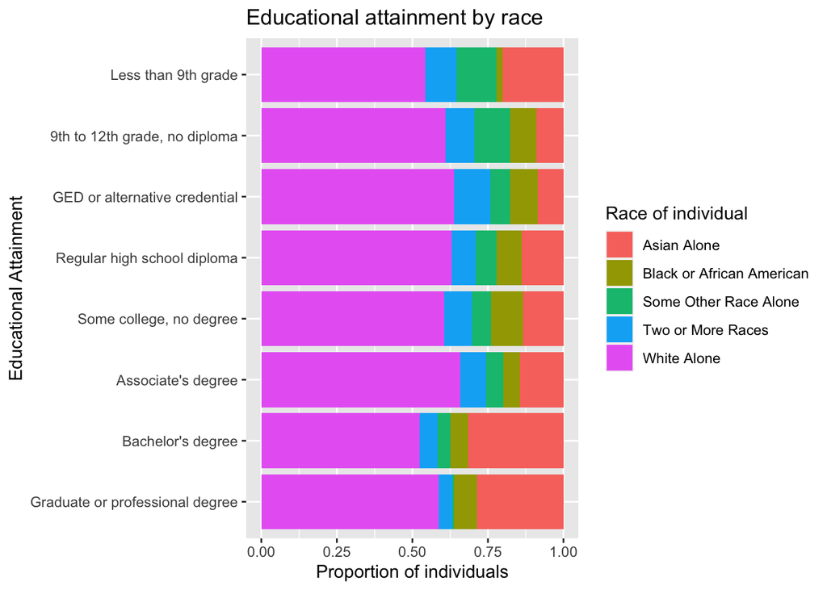

```r
### graph education by race
sjc_education_race %>%
  group_by(education, race) %>%
  summarize(estimate = sum(estimate)) %>%
  ggplot() +
  geom_bar(
    aes(
      x = education,
      y = estimate,
      fill = race
    ),
    stat = "identity",
    position = "fill"
  ) +
  labs(
    x = "Educational Attainment",
    y = "Proportion of individuals",
    title = "Educational attainment by race",
    fill = "Race of individual"
  )+
  coord_flip()
```

- Note: these racial options do not disaggregate by ethnicity, and thus overlook Latinx residents. Latinx residents make up a significant proportion of San Joaquin County residents.

*- An estimate of the number and percentage of K-12 students who have no internet access at home, using the latest available PUMS data. (Note that 2019 1-yr PUMS data will be available in mid-October 2020, so you might choose to update your analysis using that data at that time.) State your assumptions clearly, especially how useful the available data is for understanding the challenges of remote learning in 2020. Include a map of this metric for all PUMAs in the Bay Area.*

```r
### after collecting CA PUMS data (hidden beacuse of the frequent progress updates), isolating to Bay Area
ca_pumas <-
  pumas("CA", cb = T, progress_bar = F)

bay_pumas <-
  ca_pumas %>%
  st_centroid() %>%
  .[bay_counties, ] %>%
  st_set_geometry(NULL) %>%
  left_join(ca_pumas %>% select(GEOID10)) %>%
  st_as_sf()
```

```
## although coordinates are longitude/latitude, st_intersects assumes that they are planar
## although coordinates are longitude/latitude, st_intersects assumes that they are planar
```

```r
bay_pums <-
  ca_pums %>%
  filter(PUMA %in% bay_pumas$PUMACE10)

bay_pums_example <-
  bay_pums %>%
  filter(!duplicated(SERIALNO)) %>%
  mutate(
    child_nointernet = ifelse(
      (ACCESS != 1) &
        (SCHG <- 01:14),
      WGTP,
      0
    )
  ) %>%
  group_by(PUMA) %>%
  summarize(
    perc_child_nointernet =
      sum(child_nointernet, na.rm =T)/sum(WGTP, na.rm = T)*100
  ) %>%
  left_join(
    bay_pumas %>%
      select(PUMACE10),
    by = c("PUMA" = "PUMACE10")
  ) %>%
  st_as_sf()
```

```r
###graph this on a map

pums_pal <- colorNumeric(
  palette = "Oranges",
  domain = bay_pums_example$perc_child_nointernet
)

leaflet() %>%
  addTiles() %>%
  addPolygons(
    data = bay_pums_example,
    fillColor = ~pums_pal(perc_child_nointernet),
    color = "white",
    opacity = 0.5,
    fillOpacity = 0.5,
    weight = 1,
    label = ~paste0(
      round(perc_child_nointernet),
      "% K-12 students without access to internet"
    ),
    highlightOptions = highlightOptions(
      weight = 2,
      opacity = 1
    )
  ) %>%
  addLegend(
    data = bay_pums_example,
    pal = pums_pal,
    values = ~perc_child_nointernet,
    title = "% K-12 students in households w/o access to internet"
  )
```

[interactive chart not shown]

Overall, we see between 5-20% of K-12 students in the Bay Area live in households without access to internet. This proportion seems to be significantly higher in parts of East Oakland (27%) and San Francisco (Hunters Points - 15% and Potrero Hill - 22%).

*- A migration analysis, as demonstrated in 2.3, using data on educational attainment. Discuss what you believe can be interpreted from the results of this methodology, especially as it relates to the “educational mobility” of Bay Area residents.*

```r
library (knitr)

Sys.setenv(CENSUS_KEY="8a30b488e19d78df02c748f4833ec25ed94fffa6")

acs_vars_2019_1yr <-
  listCensusMetadata(
    name = "2019/acs/acs1",
    type = "variables"
  )

acs_vars_2018_1yr <-
  listCensusMetadata(
    name = "2019/acs/acs1",
    type = "variables"
  )




bay_edu_mobility_current_19 <-
  getCensus(
    name = "acs/acs1",
    vintage = 2019,
    region = "county:001,013,041,055,075,081,085,095,097",
    regionin = "state:06",
    vars = c("group(B07009)")
  ) %>%
  select(!c(GEO_ID,state,NAME) & !ends_with(c("EA","MA","M"))) %>%
  pivot_longer(
    ends_with("E"),
    names_to = "variable",
    values_to = "estimate"
  ) %>%
  left_join(
    acs_vars_2019_1yr %>%
      select(name, label),
    by = c("variable" = "name")
  ) %>%
  select(-variable) %>%
  separate(
    label,
    into = c(NA,NA,"mobility","educational_attainment"),
    sep = "!!",
  ) %>%
  na.omit %>%
  mutate(
    mobility = ifelse(
      mobility %in% c("Same house 1 year ago:", "Moved within same county:"),
      "Here since last year",
      "Inflow"
    ),
  ) %>%
  filter(!is.na(educational_attainment)) %>%
  group_by(mobility, educational_attainment) %>%
  summarize(estimate = sum(estimate))
bay_edu_mobility_lastyear_19 <-
  getCensus(
    name = "acs/acs1",
    vintage = 2019,
    region = "county:001,013,041,055,075,081,085,095,097",
    regionin = "state:06",
    vars = c("group(B07409)")
  ) %>%
  select(!c(GEO_ID,state,NAME) & !ends_with(c("EA","MA","M"))) %>%
  pivot_longer(
    ends_with("E"),
    names_to = "variable",
    values_to = "estimate"
  ) %>%
  left_join(
    acs_vars_2019_1yr %>%
      select(name, label),
    by = c("variable" = "name")
  ) %>%
  select(-variable) %>%
  separate(
    label,
    into = c(NA,NA,"mobility","educational_attainment"),
    sep = "!!",
  ) %>%
  na.omit %>%
  mutate(
    mobility = ifelse(
      mobility %in% c("Same house:", "Moved within same county:"),
      "Here since last year",
      "Outflow"
    ),
  ) %>%
  filter(!is.na(educational_attainment)) %>%
  group_by(mobility, educational_attainment) %>%
  summarize(estimate = sum(estimate))
bay_edu_mobility_current_18 <-
  getCensus(
    name = "acs/acs1",
    vintage = 2018,
    region = "county:001,013,041,055,075,081,085,095,097",
    regionin = "state:06",
    vars = c("group(B07009)")
  ) %>%
  select(!c(GEO_ID,state,NAME) & !ends_with(c("EA","MA","M"))) %>%
  pivot_longer(
    ends_with("E"),
    names_to = "variable",
    values_to = "estimate"
  ) %>%
  left_join(
    acs_vars_2018_1yr %>%
      select(name, label),
    by = c("variable" = "name")
  ) %>%
  select(-variable) %>%
  separate(
    label,
    into = c(NA,NA,"mobility","educational_attainment"),
    sep = "!!",
  ) %>%
  mutate(
    mobility = "Here last year") %>%
  na.omit %>%
  filter(!is.na(educational_attainment)) %>%
  group_by(mobility, educational_attainment) %>%
  summarize(estimate = sum(estimate))
bay_flows_19 <-
  rbind(
    bay_edu_mobility_current_18,
    bay_edu_mobility_lastyear_19 %>%
      filter(mobility == "Outflow"),
    bay_edu_mobility_current_19 %>%
      filter(mobility == "Inflow"),
    bay_edu_mobility_current_19 %>%
      group_by(educational_attainment) %>%
      summarize(estimate = sum(estimate)) %>%
      mutate(mobility = "Here this year")
  ) %>%
  pivot_wider(
    names_from = mobility,
    values_from = estimate
  ) %>%
  mutate(
    `External net` = Inflow - Outflow,
    `Internal net` = `Here this year` - `Here last year` - `External net`,
  ) %>%
  select(
    `Educational Attainment` = educational_attainment,
    `Internal net`,
    `External net`,
    `Here last year`,
    `Here this year`,
    Outflow,
    Inflow
  )
kable(bay_flows_19)
```

| Educational Attainment | Internal net | External net | Here last year | Here this year | Outflow | Inflow |
| --- | --- | --- | --- | --- | --- | --- |
| Bachelor’s degree | 5162 | 1012 | 1569338 | 1575512 | 104116 | 105128 |
| Graduate or professional degree | 1395 | 19098 | 1157040 | 1177533 | 77270 | 96368 |
| High school graduate (includes equivalency) | 4701 | 1195 | 878801 | 884697 | 35783 | 36978 |
| Less than high school graduate | 17857 | 1415 | 574248 | 593520 | 21179 | 22594 |
| Some college or associate’s degree | -29849 | -10449 | 1370276 | 1329978 | 64024 | 53575 |

We see significant outflows of folks who have some college or an associate’s degree.

I wonder if this could indicate that our job market in CA is currently oriented toward high skilled and informally skilled work, but not middle-skill?